Reference #1

Research Article

# Structure of DNMT1-DNA Complex Reveals a Role for Autoinhibition in Maintenance DNA Methylation

Jikui Song, Olga Rechkoblit, , Timothy H. Bestor, and Dinshaw J. Patel Authors Info & Affiliations

Science

16 Dec 2010

Vol 331, Issue 6020

pp. 1036-1040

[DOI: 10.1126/science.1195380](https://doi.org/10.1126/science.1195380)

## Abstract

Maintenance of genomic methylation patterns is mediated primarily by DNA methyltransferase-1 (DNMT1). We have solved structures of mouse and human DNMT1 composed of CXXC, tandem bromo-adjacent homology (BAH1/2), and methyltransferase domains bound to DNA-containing unmethylated CpG sites. The CXXC specifically binds to unmethylated CpG dinucleotide and positions the CXXC–BAH1 linker between the DNA and the active site of DNMT1, preventing de novo methylation. In addition, a loop projecting from BAH2 interacts with the target recognition domain (TRD) of the methyltransferase, stabilizing the TRD in a retracted position and preventing it from inserting into the DNA major groove. Our studies identify an autoinhibitory mechanism, in which unmethylated CpG dinucleotides are occluded from the active site to ensure that only hemimethylated CpG dinucleotides undergo methylation.

Maintenance of genomic methylation patterns in mammals (*1*–*3*) is required for monoallelic expression of imprinted genes (*4*), for the transcriptional silencing of retrotransposons (*5*, *6*), and for X chromosome inactivation in females (*7*). The eukaryotic maintenance DNA methyltransferase DNMT1 is a multimodular protein composed of a replication foci-targeting domain (RFD), a DNA-binding CXXC domain, a pair of bromo-adjacent homology (BAH) domains, and a C-terminal catalytic domain (Fig. 1A). We solved the structures of mouse DNMT1(650–1602) and human DNMT1(646–1600) bound to duplex DNA–containing unmethylated CG sites. Our structural studies reveal a role for autoinhibition in maintenance DNA methylation, by which occlusion of unmethylated CpG dinucleotides from de novo methylation ensures that only hemimethylated CpG dinucleotides gain access to the active site.

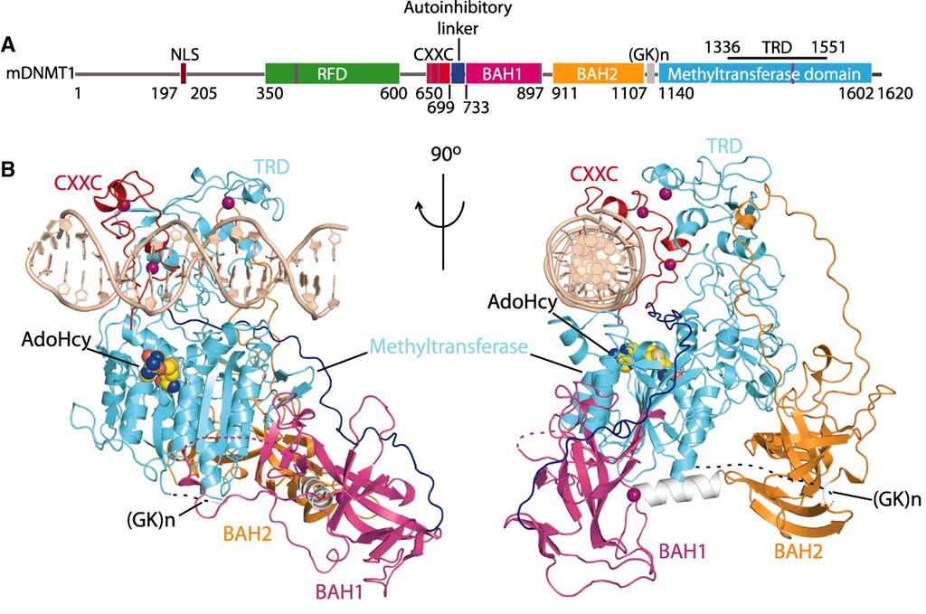

**Structures of mouse and human DNMT1-DNA complexes.** The crystal structure of an enzymatically active mouse DNMT1 (mDNMT1; residues 650 to 1602) in complex with S-adenosyl homocysteine (AdoHcy) and a 19-base pair (bp) DNA duplex was solved at 3.0 Å resolution (table S1). The DNA contained two unmethylated CpG dinucleotides separated by 8 bp. We can trace the CXXC domain (Fig. 1B, red), both BAH1 (Fig. 1B, light purple) and BAH2 (Fig. 1B, orange) domains, and the C-terminal catalytic methyltransferase domain (Fig. 1B, light blue), as well as all 19-bp of the bound DNA (Fig. 1B, light brown) (Fig. 1B and fig. S1). The CXXC and BAH1 domains are at opposite ends of the methyltransferase domain and are connected by a long linker segment (CXXC–BAH1 linker) (Fig. 1B, blue, and fig. S2). The BAH1 and BAH2 domains are separated by an α-helical linker (Fig. 1B, silver), with both BAH domains positioned on the surface remote from the bound DNA. The (GK)<sub>n</sub> linker segment that connects the BAH2 domain to the catalytic domain is disordered in the complex and is shown by a dashed line in Fig. 1B. The catalytic domain forms the core of the complex and contacts both BAH domains and the DNA. A molecule of AdoHcy (Fig. 1B) is positioned in the active site of the catalytic domain. We observed four Zn<sup>2+</sup> cations (Fig. 1B, purple balls) in the structure of the complex, two in Cys<sub>4</sub>-coordination within the CXXC domain, whereas two others involve coordination of single Zn ions in Cys<sub>3</sub>His-coordination in BAH1 and in the target recognition domain (TRD) (*8*) of the methyltransferase. The bound 19-bp DNA adopts an almost ideal B-form duplex in the complex (fig. S3). The 2.5 Å structure of mDNMT1(731–1602) lacking the CXXC domain and the CXXC-BAH1 linker in the free state (figs. S4 and S5 and table S1) is very similar to the structure of the mDNMT1(650–1602) DNA complex [Cα root mean square deviation (RMSD) of 1.0 Å over 814 aligned residues] and confirms the domain structure and relative orientations of BAH1, BAH2, and the catalytic domain. No structure has yet been reported for DNMT1 constructs bound to hemimethylated DNA.

Mouse DNMT1 and human DNMT1 (hDNMT1) exhibit 85% sequence identity (fig. S6). We have also solved the crystal structure of hDNMT1(646–1600) bound to the same 19-bp DNA and AdoHcy at 3.6 Å resolution (figs. S7 to S9 and table S2). The structures of the mouse and human proteins are very similar, with a Cα RMSD of 1.1 Å over 877 aligned residues, which is suggestive of a common mechanism of action. However, the methyltransferase domain is repositioned relative to the CXXC domain and DNA by a 1-bp translation along the DNA axis. Such differences probably arise from the flexibility of the CXXC-BAH1 linker and could also be due to the different packing environment between the two complexes.

**CXXC domain binds unmethylated CpG dinucleotides.** The CXXC domain of mDNMT1 adopts a crescent-like fold similar to that adopted by the MLL1 CXXC domain (*9*, *10*). Two short helical segments position eight Cys residues in two clusters for coordination of a pair of embedded Zn<sup>2+</sup> cations (fig. S10, A and B). All sequence-specific contacts with DNA are made via the CXXC domain in the DNMT1-DNA complex. The CXXC domain targets both the major and minor grooves of the DNA over a CpG-containing 4-bp footprint. A loop segment (Arg<sup>684</sup>-Ser<sup>685</sup>-Lys<sup>686</sup>-Gln<sup>687</sup>) from the CXXC domain penetrates into the major groove (Fig. 2, A and B) and forms base-specific and phosphodiester intermolecular interactions (Fig. 2C), which is reminiscent of the MLL1 CXXC domain interaction with DNA (*9*, *10*).

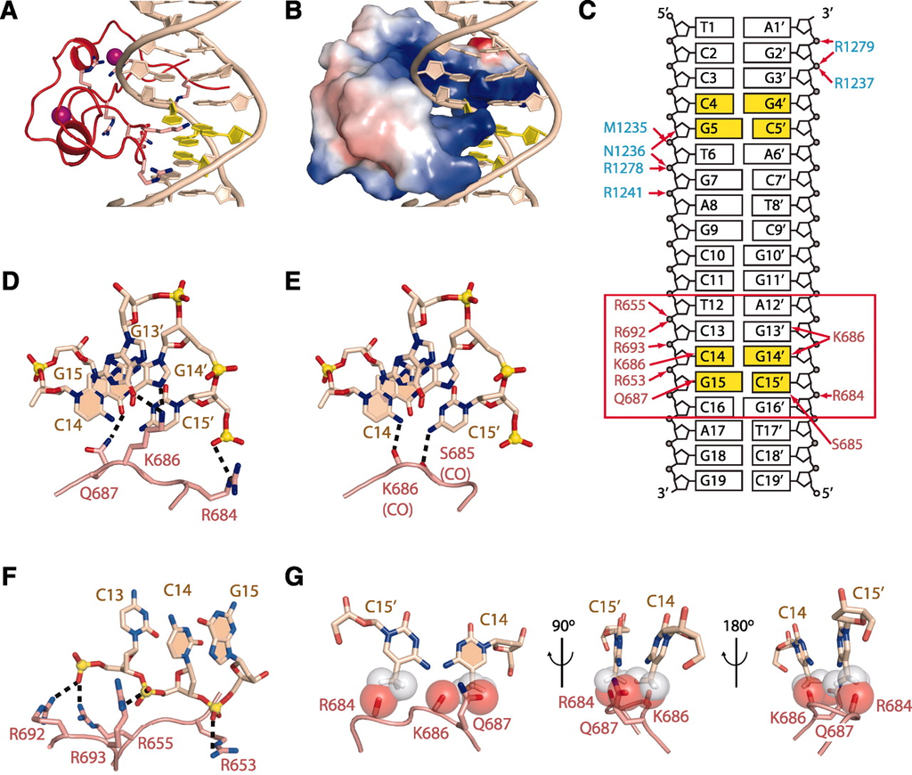

Fig. 2 Intermolecular contacts between CXXC domain of mDNMT1(650–1602) and DNA 19-nucleotide oligomer. (**A**) Ribbon representation of the CXXC domain bound to DNA. The CpG step is rendered in yellow. (**B**) Surface electrostatic representation of the CXXC domain bound to DNA. (**C**) Schematic view of intermolecular interactions involving the CXXC domain in the mDNMT1-DNA 19-nucleotide oligomer complex (boxed red rectangle), with intermolecular contacts shown by red arrows. The residue labels are colored according to their respective domains in Fig. 1. (**D**) Hydrogen-bonding interactions between side chains from the CXXC domain and the guanine base edges of the CpG step in the DNA major groove. The nitrogen, oxygen, and phosphorous atoms are shown in dark blue, red, and yellow, respectively. The bases of the CpG dinucleotide from one strand are shaded. (**E**) Hydrogen-bonding interactions between backbone carbonyl oxygens from the CXXC domain and cytosine amino groups of the CpG step in the DNA major groove. (**F**) Hydrogen-bonding interactions between arginine side chains of the CXXC domain and the phosphodiester backbone of the DNA along the DNA minor groove. (**G**) Potential steric clashes between methylated cytosine modeled on either strand of the CpG step and the CXXC domain of DNMT1 in the structure of the complex. Van der Waals radii are rendered in red for DNMT1 and gray for modeled methylated cytosine.

The guanine bases in the CpG dinucleotide are recognized by side-chain interactions involving Lys<sup>686</sup> and Gln<sup>687</sup> of the CXXC domain (Fig. 2D), whereas the cytosine bases in the CpG dinucleotide are recognized by backbone interactions involving Ser<sup>685</sup> and Lys<sup>686</sup> of the CXXC domain (Fig. 2E). DNA recognition is further anchored by salt bridges between arginine side chains of the CXXC domain and the phosphodiester backbone of the DNA [Fig. 2F and supporting online material (SOM) text] (*11*). The CXXC domain has been reported to specifically bind unmethylated CpG dinucleotides (*9*, *12*–*14*). Our structural data confirms this conclusion: Methylation of either cytosine in the CpG step would create severe steric clashes with peptide atoms (Fig. 2G).

**Comparison of mDNMT1-DNA and M.*Hha*I-DNA complexes.** We have compared the structure of the mDNMT1(650–1602)–DNA 19-nucleotide oligomer complex (Fig. 3A, TRD and catalytic core only) with the published structure (*15*) of the M.*Hha*1-DNA complex (Fig. 3B). An overlay of these two complexes is shown in stereo in Fig. 3C, after superposition of the catalytic cores of their methyltransferase domains (Cα RMSD = 2.0 Å over 218 aligned residues). Five (I, VI, VIII, IX, and X) out of six conserved sequence motifs of mDNMT1 adopt conformations very similar to those of their counterparts in M.*Hha*I (fig. S14, A and C to F). Motif IV, which is part of the catalytic loop and contains the catalytic Cys residue, in contrast adopts different conformations in the two complexes (fig. S14B).

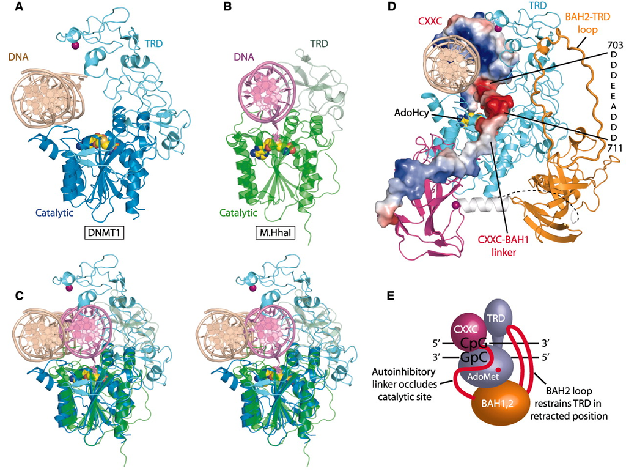

With respect to the methyltransferase domains, the bound DNAs in M.*Hha*I and mDNMT1 complexes align in the same orientation along the DNA axis, but the unmethylated DNA (Fig. 3, light brown) in the mDNMT1 complex is displaced laterally (by the width of a DNA duplex) so that it is positioned further away from the active site (Fig. 3, A and C). In the M.*Hha*I complex, the DNA (Fig. 3, light purple) is embedded within the cleft formed by the catalytic core and the TRD domain, with the target cytosine inserted into the active site (Fig. 3, B and C, and fig. S15A). The DNA in the structure of the mDNMT1 complex (Fig. 3, light brown) is anchored by the CXXC domain in a position that is distant from the active site of DNMT1 (fig. S15B). The exclusion of the unmethylated DNA from the active site is the result of an autoinhibitory CXXC-BAH1 linker, which contains a highly acidic segment spanning residues D703 to D711 and is positioned directly between the DNA and the active site (Fig. 3D; the CXXC domain and the CXXC-BAH1 linker are presented in an electrostatic surface representation) (*16*).

The mDNMT1 and M.*Hha*I TRD subdomains have little sequence similarity (fig. S11A) and exhibit the greatest structural divergence. They both contain a common 8–amino acid DNA recognition loop, whereas a second 8–amino acid DNA recognition loop in M.*Hha*I is replaced by a longer 73–amino acid loop in mDNMT1 (fig. S16, A and B). In our structure of the mDNMT1-DNA complex, the TRD subdomain is held in a retracted position away from the DNA through interaction with the BAH2-TRD loop (Figs. 1B and 3D and fig. S12, A and B).

**BAH domains.** The BAH1 and BAH2 domains of mDNMT1 are connected by an α-helix and are arranged in a dumbbell configuration (Fig. 1B, right). Despite low sequence conservation (fig. S17A), both BAH domains adopt a common fold (fig. S17, B to D) that is similar to the Orc1p BAH domain (fig. S17E) (*17*, *18*). In addition, a Cys<sub>3</sub>His-coordinated Zn<sup>2+</sup> anchors the BAH1 domain to the linker α-helix (fig. S10C).

Both BAH domains are physically associated with the methyltransferase domain (Fig. 1B and fig. S12). In the BAH2 domain, a long loop (BAH2-TRD loop) (Fig. 1B and figs. S12A and S18) projects upward and is anchored near its tip to the TRD of the methyltransferase domain (Fig. 3D and fig. S12A). This interaction is predicted to prevent the interaction of the TRD with DNA (Fig. 1B and fig. S12, A and B). BAH1 and BAH2 domains present a large accessible surface area that is peripheral to the catalytic domain (Fig. 1B) and could serve as a platform for interactions with other proteins.

**Enzymatic activities of wild-type, truncated, and mutant DNMT1.** We have used enzymatic methylation assays on full-length, truncated, and mutant DNMT1 (Fig. 4 and fig. S19) to test predictions derived from the structural data. We have used a 14-nucleotide oligomer DNA duplex that contains a single CpG dinucleotide in the hemimethylated or unmethylated state (Fig. 4B). Enzymatic assays have been done on truncated mDNMT1 (Fig. 4C), truncated hDNMT1, commercially purchased full-length hDNMT1 (fig. S19), and on both unmethylated and hemimethylated 14-nucleotide oligomer DNA substrates, with the steady-state Michaelis-Menten kinetic parameters listed in table S3.

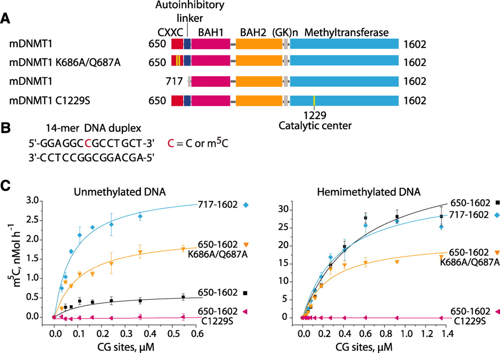

Fig. 4 Efficiency of unmethylated and hemimethylated DNA m5C-methylation by mouse wild-type and mutant DNMT1 proteins. (**A**) Domain structures of mouse DNMT1 proteins used for activity assay. The Lys<sup>686</sup>Ala/Gln<sup>687</sup>Ala and Cys<sup>1229</sup>Ser mutations are shown as yellow bars. (**B**) Sequence of 14-nucleotide oligomer DNA duplex used for enzymatic assay. (**C**) Enzyme kinetics on de novo and maintenance methylation of DNMT1 mutants after removal or mutation of CXXC domain. Rates of <sup>3</sup>H-CH<sub>3</sub> in nMol per hour transferred to unmethylated and hemimethylated DNA duplexes by 1 nM of mDNMT1(650–1602) wild-type, Lys<sup>686</sup>Ala/Gln<sup>687</sup>Ala and Cys<sup>1229</sup>Ser mutants and mDNMT1(717–1602) proteins were plotted as a function of CpG site concentration; the steady-state Michaelis-Menten parameters that were estimated from these plots are listed in table S3. Each reaction point was repeated in triplicate; mean and SD values are shown.

We found that the initial rate *k*<sub>cat</sub> for unmethylated and hemimethylated substrate was 0.25 ± 0.04 and 18 ± 2 hour<sup>–1</sup>, respectively, for full-length (1–1616) hDNMT1 (fig. S19 and table S3). The values for truncated (646–1600) hDNMT1 were 0.18 ± 0.02 and 12 ± 1 hour<sup>–1</sup>. These data confirm that the activities and preference for hemimethylated substrates were comparable for the full-length and truncated proteins.

The cocrystal structure of mDNMT1-DNA complex showed that the CXXC domain and CXXC-BAH1 linker occlude DNA from the active site. We tested mDNMT1 proteins composed of amino acids 717–1602 (CXXC domain and a segment of the CXXC-BAH1 linker deleted) and found that *k*<sub>cat</sub> on unmethylated substrates increased from 0.60 ± 0.03 hour<sup>–1</sup> for the 650–1602 protein to 3.3 ± 0.2 hour<sup>–1</sup> for 717–1602 (Fig. 4C, left, and table S3). In contrast, there is a modest drop in *k*<sub>cat</sub> on hemimethylated 14-nucleotide oligomer DNA on proceeding from 650–1602 (*k*<sub>cat</sub> = 45 ± 6 hour<sup>−1</sup>) to 717–1602 (*k*<sub>cat</sub> = 36 ± 3 hour<sup>−1</sup>) mDNMT1 (Fig. 4C, right, and table S3). Thus, the relative preference for hemimethylated over unmethylated 14-nucleotide oligomer DNA drops sevenfold on proceeding from mDNMT1 construct 650–1602, to 717–1602 (table S3).

In addition, residues that contact guanosine bases within the CpG site were mutated to abolish these contacts (mDNMT1 650–1602, K686A/Q687A double mutant), which was confirmed by gel shift assay (fig. S20). This mutant protein also showed a related increase in *k*<sub>cat</sub> (2.1 ± 0.2 hour<sup>−1</sup>) on unmethylated substrates and a modest decrease in *k*<sub>cat</sub> (22 ± 2 hour<sup>−1</sup>) on hemimethylated subtrates (Fig. 4C and table S3)—thus, the preference for hemimethylated over unmethylated 14-nucelotide oligomer DNA drops sixfold for mDNMT1(650–1602) on proceeding from wild-type to the CXXC-containing dual mutant (table S3).

**Autoinhibition in maintenance DNA methylation.** Our findings allow us to propose a mechanism for autoinhibitory regulation of DNMT1 at unmethylated CpG sites on DNA: Unmethylated DNA is excluded from the active site of mDNMT1 by the binding of the CXXC domain, whereas the presence of the acidic autoinhibitory CXXC-BAH1 linker positioned directly between the DNA and the active site prevents entrance of DNA into the catalytic pocket (Fig. 3D). Further, the BAH2-TRD loop anchors the TRD (Fig. 3D) in a retracted position (Fig. 3A) and prevents it from binding in the DNA major groove.

Maintenance methylation is tightly coupled to DNA replication (*19*). We propose that unmethylated CpG sites are protected from de novo methylation through binding by the CXXC domain as CpG dinucleotides emerge from the replication complex. This increases the efficiency of maintenance methylation through inhibition of de novo methylation.

The research was supported by funds from the Abby Rockefeller Mauze Trust and Maloris Foundation to D.J.P. and from NIH to T.H.B. We thank S. Murakami for technical assistance and Z. Wang and H. Li for their assistance with x-ray data collection and structure determination. We would also like to thank the staff of NE-CAT beamlines at the Advanced Photon Source, Argonne National Laboratory, and the X-29 beamline at the Brookhaven National Laboratory, for access and assistance with data collection. The structures of the complexes have been deposited in the Protein Data Bank (PDB). The accession codes are mDNMT1(650–1602)–DNA complex with bound AdoHcy (3PT6), hDNMT1(646–1600)–DNA complex with bound AdoHcy (3PTA) and mDNMT1(731–1602) with bound AdoHcy (3PT9).

## Supplementary Material

File (song-som.pdf)

- [Download](https://www.science.org/doi/suppl/10.1126/science.1195380/suppl_file/song-som.pdf)
- 3.15 MB

## Supporting Online Material

Materials and Methods

SOM Text

Figs. S1 to S21

Tables S1 to S3

References

## References and Notes

1

Law J. A., Jacobsen S. E., Establishing, maintaining and modifying DNA methylation patterns in plants and animals. *Nat. Rev. Genet.* *11*, 204 (2010).

GO TO REFERENCE

[Crossref](https://doi.org/10.1038/nrg2719)

[PubMed](https://pubmed.ncbi.nlm.nih.gov/20142834/)

Web of Science

Google Scholar

[figure not shown]

2

Cheng X., Blumenthal R. M., Mammalian DNA methyltransferases: A structural perspective. *Structure* *16*, 341 (2008).

[Crossref](https://doi.org/10.1016/j.str.2008.01.004)

[PubMed](https://pubmed.ncbi.nlm.nih.gov/18334209/)

Web of Science

Google Scholar

[figure not shown]

3

Goll M. G., Bestor T. H., Eukaryotic cytosine methyltransferases. *Annu. Rev. Biochem.* *74*, 481 (2005).

GO TO REFERENCE

[Crossref](https://doi.org/10.1146/annurev.biochem.74.010904.153721)

[PubMed](https://pubmed.ncbi.nlm.nih.gov/15952895/)

Web of Science

Google Scholar

[figure not shown]

4

Li E., Beard C., Jaenisch R., Role for DNA methylation in genomic imprinting. *Nature* *366*, 362 (1993).

GO TO REFERENCE

[Crossref](https://doi.org/10.1038/366362a0)

[PubMed](https://pubmed.ncbi.nlm.nih.gov/8247133/)

Web of Science

Google Scholar

[figure not shown]

## (0)eLetters

No eLetters have been published for this article yet.

  Jikui Song, Science, 2012
- Nascent DNA methylome mapping reveals inheritance of hemimethylation at CTCF/cohesin sites

  Chenhuan Xu, Science, 2018
- DNA Methylation de Novo

  Adrian Bird, Science, 1999
- UHRF1 Plays a Role in Maintaining DNA Methylation in Mammalian Cells

  Magnolia Bostick, Science, 2007
- Substrate deformation regulates DRM2-mediated DNA methylation in plants

  Yanjing Li, Protein & Cell, 2023
- METTL14 is a chromatin regulator independent of its RNA N6-methyladenosine methyltransferase activity

  Xiaoyang Dou, Protein & Cell, 2023
- The progress on the estimation of DNA methylation level and the detection of abnormal methylation

  Shicai Fan, Quantitative Biology, 2022
- Nuclear peripheral chromatin-lamin B1 interaction is required for global integrity of chromatin architecture and dynamics in human cells

  Journal of Fisheries of China, 2023